# FNU ANDRIA GRACE

## 1a) Write out lnL(B) for logistic regression. Omit the constant term and use one regressor so that the model has only one parameter, B.

The log-likelihood function ln L(B) for logistic regression with one regressor and one parameter B:

Let, Yi denote the binary response variable for the ith observation, Xi denote the value of the regressor for the ith observation.

The logistic regression model assumes:

P(Yi = 1∣Xi) = 1 / (1 + e^−(BXi)

P(Yi = 0∣Xi) = 1 − 1 + e^−(Bxi)

The likelihood function for a single observation i:

Li(B) = Yiln (1 / (1 + e^−(Bxi)) + (1- Yi)ln (1 − (1 / 1 + e^−(Bxi))

Taking the natural logarithm of the likelihood function, we get:

lnLi(B) =Yiln (1 / (1+ e^−(Bxi)) + (1 − Yi)ln (1 − (1 / 1 + e^−(Bxi))

The log-likelihood function for all observations can be obtained by summing over all observations:

lnL(B) = n ∑ i=1 lnLi(B)

Where n is the total number of observations.

## 1b) Also write it using NumPy in a Python function like "log_likelihood(x,y,B)".

```python
import numpy as np

def log_likelihood(x, y, B):

    # Calculating the logistic function
    logistic_func = 1 / (1 + np.exp(-B * x))

    # Calculating the likelihood for each observation
    log_likelihoods = y * np.log(logistic_func) + (1 - y) * np.log(1 - logistic_func)

    # Summing over all observations to get the total log-likelihood
    total_log_likelihood = np.sum(log_likelihoods)

    return total_log_likelihood
```

## 1c) Generate some data with

### n = 100

### x = np.random.uniform(size=(n,))

### Y = 1*(x + 1*np.random.normal(size=(n,))>.5)

```python
import numpy as np

# The number of observations
n = 100

# Generating x values from a uniform distribution
x = np.random.uniform(size=(n,))

# Generating noise for y
noise = 1 * np.random.normal(size=(n,))

# Generating y values based on x with noise
y = 1 * (x + 1 * noise > 0.5)

print("Generated data:")
print("x:", x)
print("y:", y)
```

```
Generated data:
x: [0.98212305 0.75210529 0.57801814 0.55673444 0.89987705 0.95442215
 0.76888623 0.07528161 0.3857188  0.95976764 0.47681231 0.82820572
 0.1065683  0.81946914 0.08580799 0.06690732 0.44472741 0.33845153
 0.59128171 0.26519782 0.72336742 0.88844738 0.58296788 0.53957257
 0.64940708 0.30123779 0.61071919 0.26776952 0.23251338 0.71063467
 0.83257975 0.20351828 0.33150634 0.3817353  0.80329633 0.47468001
 0.90061171 0.70584771 0.58151219 0.50351964 0.94441643 0.24624459
 0.53272504 0.01357518 0.81679054 0.19887643 0.69211459 0.99515666
 0.05892392 0.50114388 0.57815632 0.05020405 0.42084858 0.84860371
 0.4284934  0.13027702 0.76054799 0.34766654 0.51954501 0.62508459
 0.14331421 0.39182423 0.85724548 0.82149207 0.43191197 0.7540569
 0.65661438 0.37506856 0.10465783 0.43074231 0.12691638 0.16817078
 0.23978365 0.37159701 0.188987   0.77908809 0.44414301 0.30629396
 0.27905993 0.57358991 0.59672141 0.2099226  0.53602608 0.82745222
 0.90181005 0.58598832 0.63685445 0.99330636 0.94278871 0.69746821
 0.5835366  0.46590157 0.46645272 0.89231658 0.77821963 0.6641779
 0.30102413 0.94050095 0.80562547 0.79371647]
y: [1 1 0 0 1 1 1 0 1 1 0 1 0 1 0 1 0 0 0 0 1 0 0 1 1 1 0 0 0 1 0 0 1 0 1 0 1
 1 0 1 1 0 0 0 1 0 1 1 1 1 0 1 0 1 1 0 1 1 0 0 0 0 0 0 0 1 1 1 0 0 1 0 1 1
 0 1 1 1 1 1 0 0 0 0 0 1 1 1 0 1 1 0 1 1 1 0 1 0 0 1]
```

## d) Compute log_likelihood() for many values of B (ex., using np.arange() or np.linspace()) and plot lnL vs. B. Which value of B should you choose as the estimate of beta, the parameter of the model?

[output not shown]

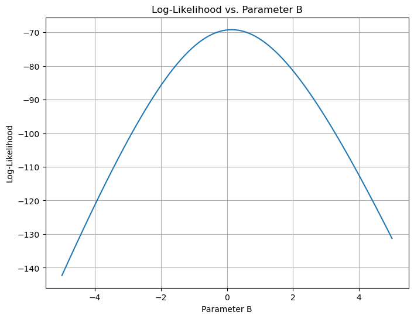

```python
import numpy as np
import matplotlib.pyplot as plt

# log-likelihood function
def log_likelihood(x, y, B):
    logistic_func = 1 / (1 + np.exp(-B * x))
    log_likelihoods = y * np.log(logistic_func) + (1 - y) * np.log(1 - logistic_func)
    total_log_likelihood = np.sum(log_likelihoods)
    return total_log_likelihood

# Generating data
n = 100
x = np.random.uniform(size=(n,))
noise = 1 * np.random.normal(size=(n,))
y = 1 * (x + 1 * noise > 0.5)

# Range of B values
B_values = np.linspace(-5, 5, 100)

# Calculating log-likelihood for each B value
log_likelihood_values = [log_likelihood(x, y, B) for B in B_values]

# Plotting log-likelihood vs. B
plt.figure(figsize=(8, 6))
plt.plot(B_values, log_likelihood_values)
plt.title('Log-Likelihood vs. Parameter B')
plt.xlabel('Parameter B')
plt.ylabel('Log-Likelihood')
plt.grid(True)
print("Estimated value of beta (parameter B):", estimated_beta)
plt.show()
```

[output not shown]